# Project3 Education Level: Elementary or less

Angelice Floyd and Michael Dolan

# Introduction

The purpose of this document is to create multiple reports that will summarizing and create various models for a CDC dataset that contains information on diabetes. Each report will cover a different education level based on a variable in the dataset, and the creation of these reports will be automated so that the same graphs and models will be generated for each education level. An EDA will be conducted to investigate some interesting variables from the dataset.

The end goal of this report is to ultimately chose the best performing model for each education level. This will be done programmatically and will be based on Log-Loss, a metric that is explained within this report.

## Dataset Overview and Variables

The information being analyzed is from the Behavioral Risk Factor Surveillance System (BRFSS), a health-related telephone survey that is collected annually by the Centers for Disease Control and Prevention (CDC). This survey has collected responses from over 400,000 Americans each year on various health-related questions since 1984.

The particular dataset being used for this report contains data from the BRFSS conducted in 2015. The dataset has been cleaned and contains responses from 253,680 survey participants. The dataset contains a total of 22 variables, many of which are binary in nature. Below is a summary of the variables present in the dataset along with their levels:

## R Packages Used

Below are all the packages used throughout this document:

```r
library(tidyverse)
library(caret)
library(GGally)
library(shiny)
library(rmarkdown)
library(MASS)
library(glmnet)
library(randomForest)
library(xgboost)
library(corrplot)
```

# Reading in the Data

```r
initial_dta <- read_csv('diabetes_binary_health_indicators_BRFSS2015.csv') %>%
          mutate(Education_1 = ifelse(Education %in% c(1,2),1,Education)) %>%
          mutate(Education_Level = ifelse(Education_1==1, "Elementary or less",
                                    ifelse(Education_1==3, "Some high school",
                                    ifelse(Education_1==4, "High school graduate",
                                    ifelse(Education_1==5, "Some college or technical school",
                                    ifelse(Education_1==6, "College graduate", "ERROR")))))) %>% dplyr::select(-Education, -Education_1)

filtered_dta <-  initial_dta %>% filter(Education_Level == "Elementary or less")  %>% dplyr::select(-Education_Level)

#set seed for reproducibility

set.seed(90)

#Convert all the categorical and binary variables to factors

cols <- c("Diabetes_binary","PhysActivity","AnyHealthcare","HighBP",
          "Smoker","Fruits","NoDocbcCost","Income","DiffWalk","HighChol","Stroke",
          "Veggies","GenHlth","Sex","CholCheck","HeartDiseaseorAttack","HvyAlcoholConsump",
          "Age")

filtered_dta[cols] <- lapply(filtered_dta[cols],as.factor)

#Ensure that all numerical variables are numeric

filtered_dta$BMI <- as.numeric(filtered_dta$BMI)
filtered_dta$MentHlth <- as.numeric(filtered_dta$MentHlth)
filtered_dta$PhysHlth <- as.numeric(filtered_dta$PhysHlth)

#Name the levels of the Diabetes_binary variable
levels(filtered_dta$Diabetes_binary)=c("No","Yes")

#create a training index that uses 70% of the data for training data

trainindex <- createDataPartition(filtered_dta$Diabetes_binary,p = 0.70, list= FALSE)

#Now, split the data into 70% training and 30% testing

initial_train <- filtered_dta[trainindex, ]
initial_test <- filtered_dta[-trainindex, ]

#To help make our predictions valid, we are now going to standardize the numeric variables

preprocval <- preProcess(initial_train,method = c("center","scale"))

trainTransformed <- as_tibble(predict(preprocval,initial_train))

testTransformed <- as_tibble(predict(preprocval,initial_test))
```

# Exploratory Data Analysis

Because this Diabetes response variable is in binary form, contingency tables and categorical visuals will be helpful since it will show how the different levels of those with and without diabetes compare to each other over levels of other categorical variables, as well as how values for the numerical variables compare at different levels for those with or without diabetes.

## Correlation Matrix

Looking at the correlation between numerical predictor variables can help in determining which variables to include in a regression model. Including predictor variables that are highly correlated with one another, known as multicollinearity, can increase the complexity of the model unnecessarily by including variables that are redundant. It can also lead to more uncertainty and variability in the model because it may be unclear which predictor variable is responsible for the effect on the target variable. To address multicollinearity, solutions like techniques like principal component analysis (PCA) can be use to mitigate the impact highly correlated predictor variables on the resulting model.

The below code creates a correlation matrix of the three numerical variables from the dataset, as well as some the categorical variables age and income, since there categories are ordinal and have enough granularity in the grouping to look at a correlation:

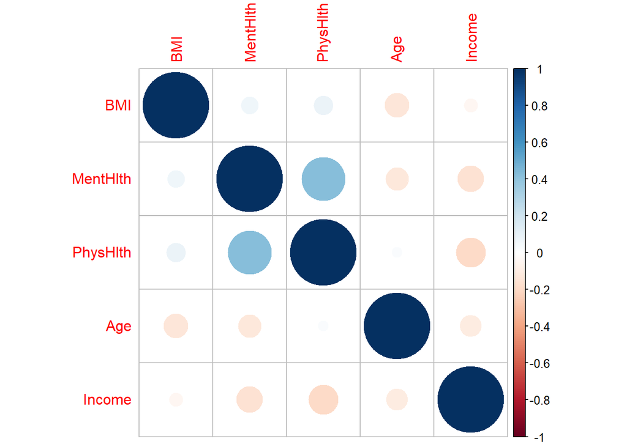

```r
cor_data <- filtered_dta

cor_data$Age <- as.numeric(cor_data$Age)
cor_data$Income <- as.numeric(cor_data$Income)

Correlation <- cor(dplyr::select(cor_data, BMI, MentHlth, PhysHlth, Age, Income), method="spearman")

corrplot(Correlation)
```

In analyzing the different variables and their correlations, their isn’t a strict cutoff, but generally speaking a correlation above 0.7-0.8 (positive or negative) would be considered high. If there are variables with correlations on the higher side (closer to 1 or -1), any models that incorporate both of these variables as predictors should be interpreted with caution.

## Overview of Numerical Variables by Sex

The below tables shows the frequency of respondents by sex among those who have diabetes and among those who do not have diabetes. This gives a general overview of the data that may be helpful to add context to the boxplots to follow.

```r
as.data.frame(table(filtered_dta$Diabetes_binary, filtered_dta$Sex)) %>% rename(Diabetes_binary="Var1", Sex = "Var2", Sex_Freq = "Freq")
```

```
##   Diabetes_binary Sex Sex_Freq
## 1              No   0     1576
## 2             Yes   0      707
## 3              No   1     1411
## 4             Yes   1      523
```

The below boxplots look at the numerical variables from the dataset with regard to distribution and center among those with and without diabetes. These boxplots are also broken out by sex to investigate the impact of this variable on the resulting distribution and center of BMI, mental health, and physical health. There are also summary statistics of mean, standard deviation, 1st quartile, median, and 3rd quartile to accompany each boxplot.

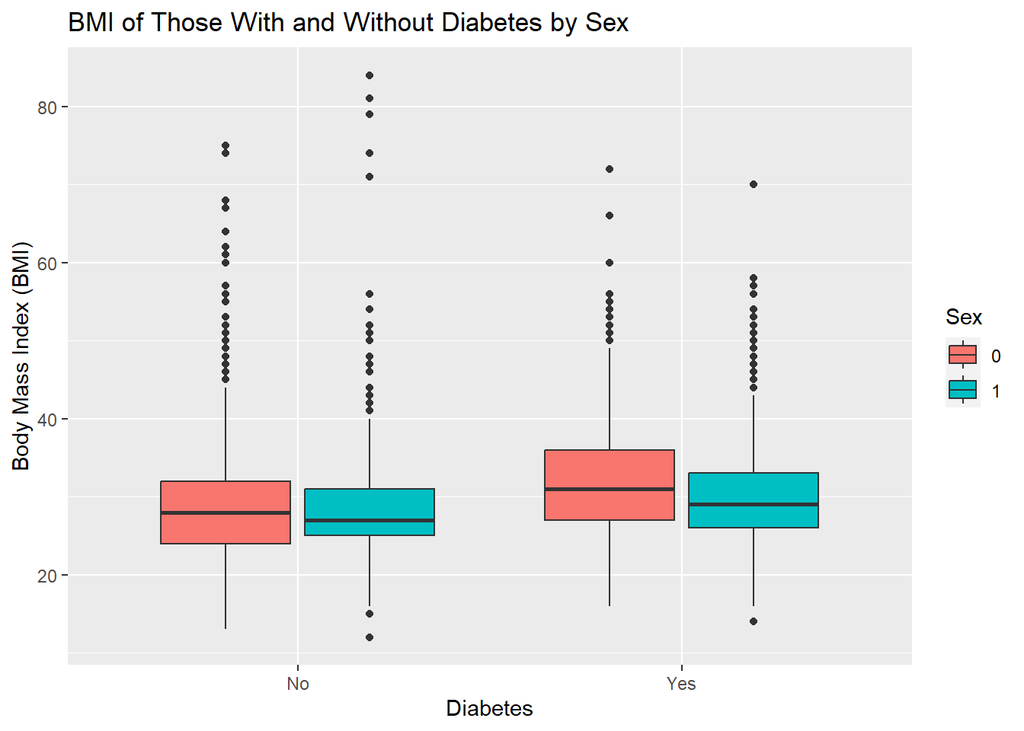

```r
ggplot(filtered_dta, aes(x=as.factor(Diabetes_binary), y=BMI,
                        fill=as.factor(Sex))) +
  geom_boxplot() +
  labs(x = "Diabetes", y = "Body Mass Index (BMI)", title = "BMI of Those With and Without Diabetes by Sex")+
  scale_fill_discrete(name="Sex")
```

```r
filtered_dta %>% group_by(Diabetes_binary, Sex) %>% summarize(BMI_mean = mean(BMI), BMI_sd = sd(BMI), BMI_Q1 = quantile(BMI, probs =0.25), BMI_Median = quantile(BMI, probs =0.5), BMI_Q3 = quantile(BMI, probs =0.75))
```

```
## # A tibble: 4 × 7
## # Groups:   Diabetes_binary [2]
##   Diabetes_binary Sex   BMI_mean BMI_sd BMI_Q1 BMI_Median BMI_Q3
##   <fct>           <fct>    <dbl>  <dbl>  <dbl>      <dbl>  <dbl>
## 1 No              0         28.9   7.23     24         28     32
## 2 No              1         28.4   6.16     25         27     31
## 3 Yes             0         32.0   7.71     27         31     36
## 4 Yes             1         30.5   6.86     26         29     33
```

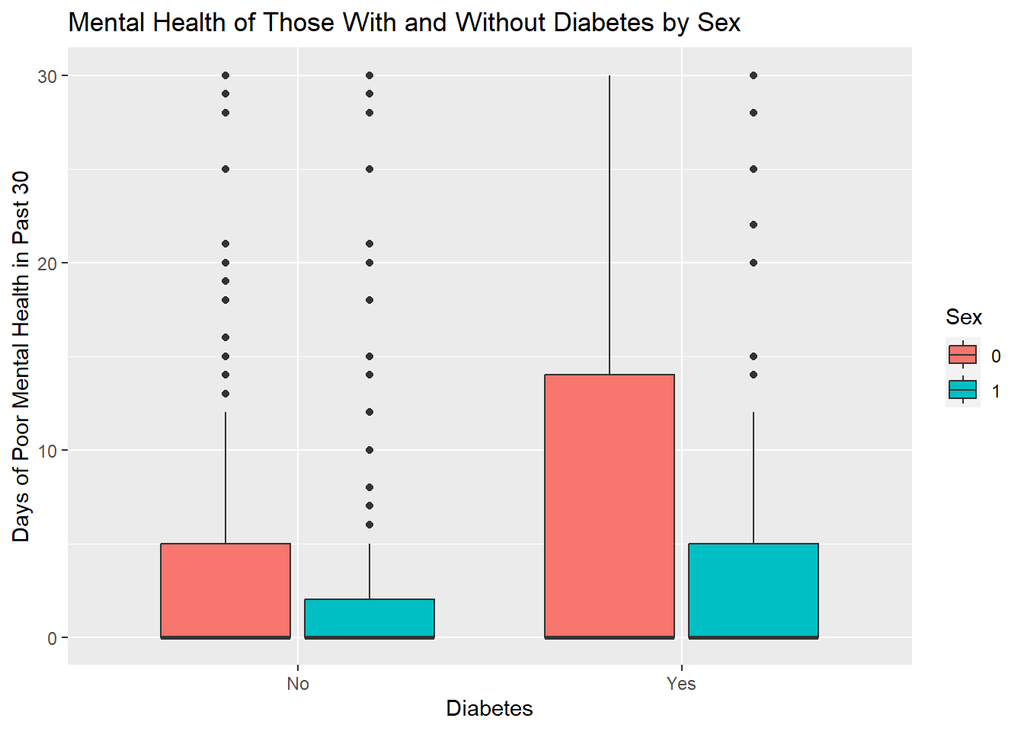

```r
ggplot(filtered_dta, aes(x=as.factor(Diabetes_binary), y=MentHlth,
                        fill=as.factor(Sex))) +
  geom_boxplot() +
  labs(x = "Diabetes", y = "Days of Poor Mental Health in Past 30", title = "Mental Health of Those With and Without Diabetes by Sex")+
  scale_fill_discrete(name="Sex")
```

```r
filtered_dta %>% group_by(Diabetes_binary, Sex) %>% summarize(MentHlth_mean = mean(MentHlth), MentHlth_sd = sd(MentHlth), MentHlth_Q1 = quantile(MentHlth, probs =0.25), MentHlth_Median = quantile(MentHlth, probs =0.5), MentHlth_Q3 = quantile(MentHlth, probs =0.75))
```

```
## # A tibble: 4 × 7
## # Groups:   Diabetes_binary [2]
##   Diabetes_binary Sex   MentHlth_mean MentHlth_sd MentHlth_Q1 MentHlth_Median
##   <fct>           <fct>         <dbl>       <dbl>       <dbl>           <dbl>
## 1 No              0              5.09        9.62           0               0
## 2 No              1              4.10        8.85           0               0
## 3 Yes             0              7.50       11.1            0               0
## 4 Yes             1              5.56       10.2            0               0
## # ℹ 1 more variable: MentHlth_Q3 <dbl>
```

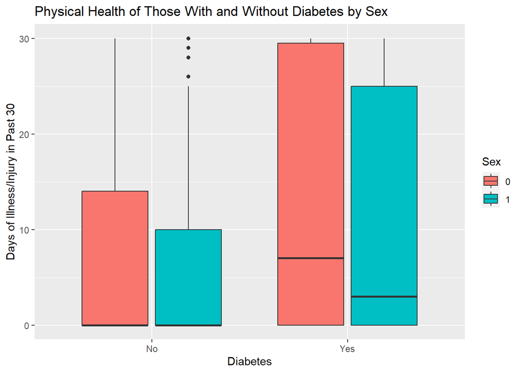

```r
ggplot(filtered_dta, aes(x=as.factor(Diabetes_binary), y=PhysHlth,
                        fill=as.factor(Sex))) +
  geom_boxplot() +
  labs(x = "Diabetes", y = "Days of Illness/Injury in Past 30", title = "Physical Health of Those With and Without Diabetes by Sex")+
  scale_fill_discrete(name="Sex")
```

```r
filtered_dta %>% group_by(Diabetes_binary, Sex) %>% summarize(PhysHlth_mean = mean(PhysHlth), PhysHlth_sd = sd(PhysHlth), PhysHlth_Q1 = quantile(PhysHlth, probs =0.25), PhysHlth_Median = quantile(PhysHlth, probs =0.5), PhysHlth_Q3 = quantile(PhysHlth, probs =0.75))
```

```
## # A tibble: 4 × 7
## # Groups:   Diabetes_binary [2]
##   Diabetes_binary Sex   PhysHlth_mean PhysHlth_sd PhysHlth_Q1 PhysHlth_Median
##   <fct>           <fct>         <dbl>       <dbl>       <dbl>           <dbl>
## 1 No              0              7.62        11.0           0               0
## 2 No              1              6.69        11.0           0               0
## 3 Yes             0             11.9         12.4           0               7
## 4 Yes             1             10.4         12.5           0               3
## # ℹ 1 more variable: PhysHlth_Q3 <dbl>
```

When analyzing these boxplots, one should look for differences in center among those with and without diabetes, as well as those among females (indicated with a 0) compared to males (indicated with a 1). One should also look for any differences in distribution among these groups. Overall, these boxplots indicate that these box plots are generally skewed right with a many outliers in the higher range of values, but distributions by education level may vary.

## Diabetes, Health Measures and Pre-Existing Conditions

It is often discussed that diet, and weight-related health issues such as obesity, high blood pressure and cholesterol are major contributing factors to diagnosis and then after complications with diabetes. When the levels for these variables are consistently high, there is often the observation that the chances for having diabetes later in life increase. Thus, it would be interesting to see how the levels of variables such as BMI, and pre existing conditions- that impact these factors- in the data interact with patients who have diabetes - and in some cases, compared to the patients who do not have diabetes.

## Diabetes Patients and Pre-Existing Conditions

The following frequency table will show the number of patients with and without diabetes who have (or do not have) high blood pressure, high cholesterol, have had stroke or have had a heart attack or heart disease.

```r
BP <- data.frame(table(filtered_dta$Diabetes_binary,filtered_dta$HighBP)) %>% rename(Diabetes_binary="Var1", High_BP = "Var2", BP_Freq = "Freq")

CHOL <- data.frame(table(filtered_dta$Diabetes_binary, filtered_dta$HighChol)) %>% rename(Diabetes_binary="Var1", High_Chol = "Var2", HI_CHOL_Freq = "Freq" )

STRKE <- as.data.frame(table(filtered_dta$Diabetes_binary, filtered_dta$Stroke)) %>% rename(Diabetes_binary="Var1", Stroke = "Var2", sTROKE_Freq = "Freq" )


HATCK <- as.data.frame(table(filtered_dta$Diabetes_binary, filtered_dta$HeartDiseaseorAttack)) %>% rename(Diabetes_binary="Var1", Heart_Disease_Attack = "Var2", Heart_Disease_Attack_Freq = "Freq" )

Diabetes_disease_frequency <- list("BP" = BP,"CHOL" = CHOL,"STRKE" = STRKE,"HATCK" = HATCK)

Diabetes_disease_frequency
```

```
## $BP
##   Diabetes_binary High_BP BP_Freq
## 1              No       0    1472
## 2             Yes       0     268
## 3              No       1    1515
## 4             Yes       1     962
##
## $CHOL
##   Diabetes_binary High_Chol HI_CHOL_Freq
## 1              No         0         1611
## 2             Yes         0          354
## 3              No         1         1376
## 4             Yes         1          876
##
## $STRKE
##   Diabetes_binary Stroke sTROKE_Freq
## 1              No      0        2777
## 2             Yes      0        1080
## 3              No      1         210
## 4             Yes      1         150
##
## $HATCK
##   Diabetes_binary Heart_Disease_Attack Heart_Disease_Attack_Freq
## 1              No                    0                      2557
## 2             Yes                    0                       853
## 3              No                    1                       430
## 4             Yes                    1                       377
```

### BMI for Patients with Diabetes

In this section, we will explore the distributions and central measures for BMI in patients with Diabetes. First we will observe the mean, median and maximum of BMI for patients with and without diabetes

```r
filtered_dta %>% summarise(Max_BMI = max(BMI), Mediam_BMI = median(BMI), Mean_BMI = mean(BMI), .by = Diabetes_binary)
```

```
## # A tibble: 2 × 4
##   Diabetes_binary Max_BMI Mediam_BMI Mean_BMI
##   <fct>             <dbl>      <dbl>    <dbl>
## 1 No                   84         28     28.7
## 2 Yes                  72         30     31.4
```

Next, we’ll look at the distribution of the BMI values ocross patients with diabetes. One thing to thnink of, is for the different educational groups- which could have a correlation with the different age groups- how is BMI distributed within this education group? Are we seeing the distribution being concentrated in the center, or are we seeing a skewness towards the higher BMI levels for these patients? Thus, can BMI be a significant predictor of diabetes ?

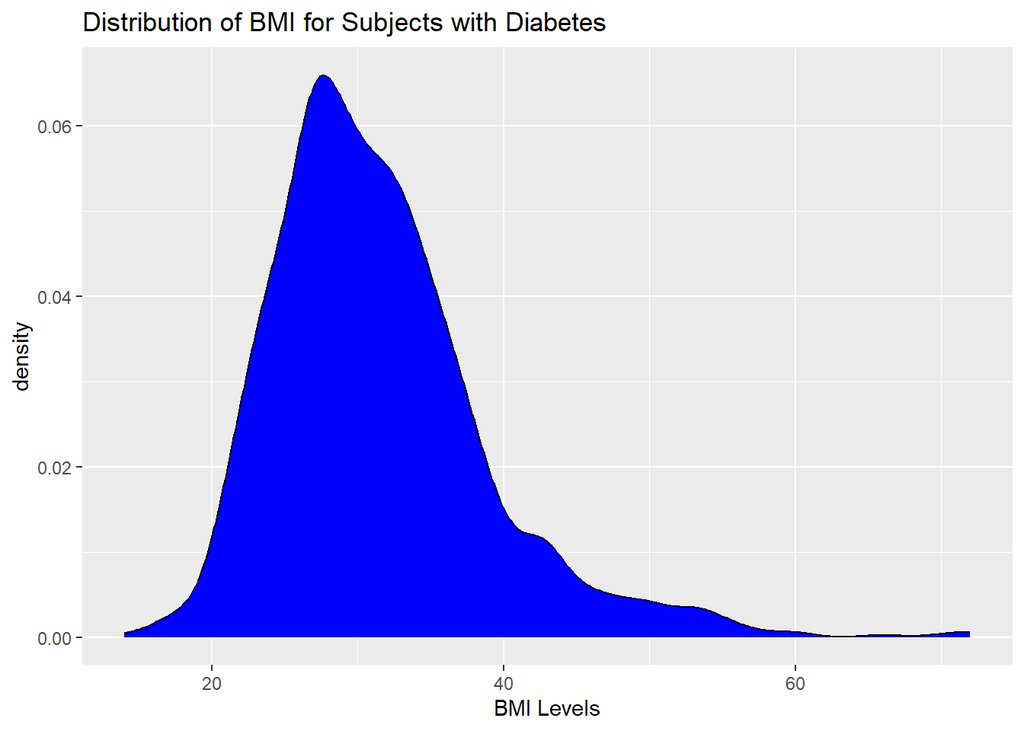

```r
diab_bmi <- filtered_dta %>% filter(Diabetes_binary == "Yes")

ggplot(diab_bmi) +
  geom_density(mapping=aes(x=BMI ), fill = "blue" ,position="identity") +
  labs(x = "BMI Levels", title = "Distribution of BMI for Subjects with Diabetes")
```

## The Case for Age

```r
PHYS <- data.frame(table(filtered_dta$Age,filtered_dta$PhysActivity)) %>% rename(Age_Group="Var1", Physical_Acitivty = "Var2", Phys_Freq = "Freq")

FRUIT <- data.frame(table(filtered_dta$Age,filtered_dta$Fruits)) %>% rename(Age_Group="Var1", Consumes_Fruit = "Var2", Fruit_Consumption_Freq = "Freq")

VEG <- data.frame(table(filtered_dta$Age,filtered_dta$Veggies)) %>% rename(Age_Group="Var1", Consumes_Veggies = "Var2", Veggie_Consumption_Freq = "Freq")


Healthy_Habits_frequency <- list("PHYS" = PHYS,"FRUIT" = FRUIT,"VEGGIES" = VEG)

Healthy_Habits_frequency
```

```
## $PHYS
##    Age_Group Physical_Acitivty Phys_Freq
## 1          1                 0         6
## 2          2                 0        13
## 3          3                 0        37
## 4          4                 0        71
## 5          5                 0        92
## 6          6                 0       123
## 7          7                 0       180
## 8          8                 0       188
## 9          9                 0       213
## 10        10                 0       220
## 11        11                 0       218
## 12        12                 0       188
## 13        13                 0       272
```

[output cut: 71 more lines]

Next, we will observe the frequency of people who have diabetes based on the healthy habits indicators moentioned above, grouped by age groups. This would give us a chance to see which population of age group held the largest value of diabetes patients, based on their health indicators. Are we seeing a consistent pattern in diabetes cases for those above or below the age ranges, or are the health and age factors playing roles in the cases? This series of bar charts might be able to provide insight.

Below observed the frequencies for whether or not a person has done physical activity in the past 30 days.

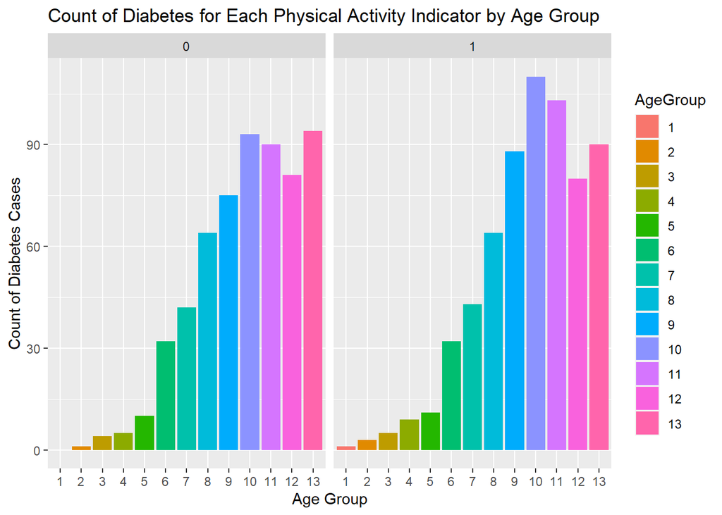

```r
initial_age_group_diab <- filtered_dta %>% filter(Diabetes_binary == "Yes")

phys_sum <- initial_age_group_diab %>% group_by(PhysActivity,Age) %>% summarize(sum_Diabetes= n())
phys_sum$AgeGroup <- as.factor(phys_sum$Age)


g <- ggplot(data = phys_sum,mapping=aes(x=AgeGroup ,y= sum_Diabetes, fill = AgeGroup), position = "dodge") +
  geom_bar(stat= "identity" ) +
  facet_wrap(~PhysActivity) +
  labs(x = "Age Group", y = "Count of Diabetes Cases", title = "Count of Diabetes for Each Physical Activity Indicator by Age Group")
g
```

Finally, this next block of code graphs the frequency of people who have diabetes based on their fruit and veggie consumption. For simplicity of this report, below will combine the Fruits and Veggies variables into one factor based variable. First, we will create a new variable that adds the Fruits and Veggies column. The factor levels will be 0, if there is no consumption at all, 1 if there is consumption in either fruits or veggies, and 2 if there is consumption in both. Then, after summarizing the data by the healthy food indicator and age group, we will produce grouped bar charts of diabetes patients for each indicator by age group.

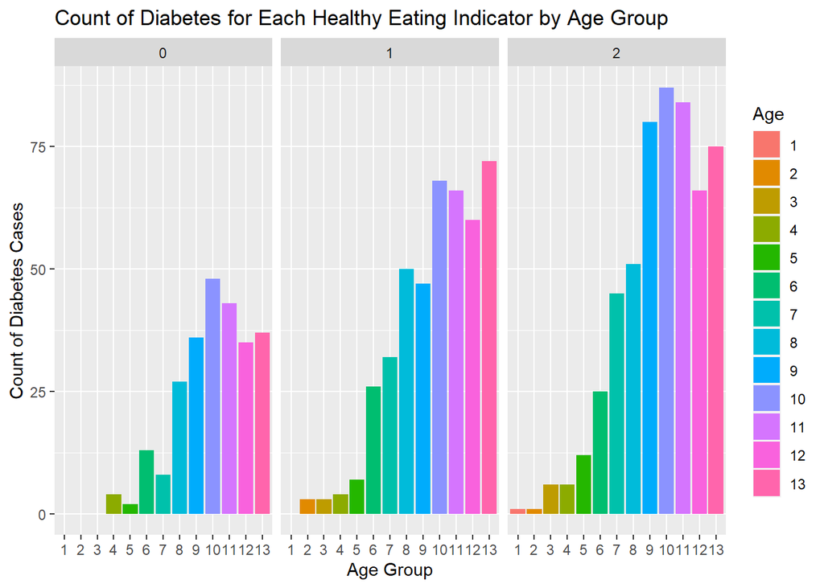

```r
initial_age_group_diab$HealthyEating <- as.numeric(as.character(initial_age_group_diab$Fruits)) + as.numeric(as.character(initial_age_group_diab$Veggies))

eat_sum <- initial_age_group_diab %>% group_by(HealthyEating,Age) %>% summarize(sum_Diabetes= n())
eat_sum$AgeGroup <- as.factor(eat_sum$Age)

g <- ggplot(data = eat_sum,mapping=aes(x=Age ,y= sum_Diabetes, fill = Age), position = "dodge") +
  geom_bar(stat= "identity" ) +
  facet_wrap(~HealthyEating) +
  labs(x = "Age Group", y = "Count of Diabetes Cases", title = "Count of Diabetes for Each Healthy Eating Indicator by Age Group")
g
```

### Age and Mental Health

So far we’ve looked at the intersections of healthy habits, age and diabetes. Finally, it would be interesting to see if mental health, age and diabetes have any intersections. The main point of interest in this portion is to see if there is any possible correlation between age and how many days during the past 30 days the subject says their mental health was not good (which is the MentHlth variable). To visualize this, below looks at a scatter plot of age and MentHlth broken out by whether or not the subject had diabetes. Is there a higher prevalence of having experiences poor mental health in the past 30 days for any particular age groups? Is there a stronger correlation for those who have diabetes compared to those who did not? These and other questions that could possibly shed light in the modelling process could be further investigated using the below set of graphs.

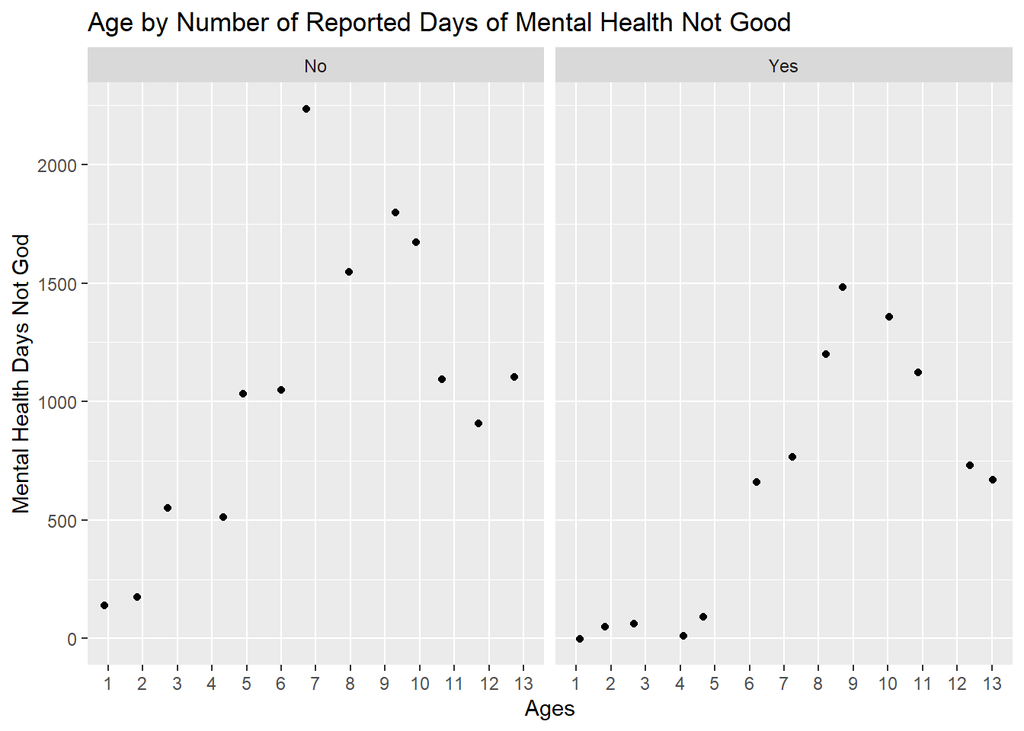

```r
ment_age <- filtered_dta %>% group_by(Diabetes_binary, Age) %>% summarize(mental_health_sum = sum(as.numeric(MentHlth)))

age_mental_scatter <- ggplot(ment_age, aes(x=Age,y=mental_health_sum)) +
  geom_point(position= "jitter") +
  geom_smooth(method = lm) +
  labs(x = "Ages", y= "Mental Health Days Not God", title= "Age by Number of Reported Days of Mental Health Not Good") +
  facet_wrap(~Diabetes_binary)


age_mental_scatter
```

# Summarization and Modelling

## Log Loss

When working with data (such as the diabetes data we are using), that contains a binary response variable with the possible outcome of 0 or 1 (occurrence or no occurrence) one of the main goals in machine learning is to fit a model whose predictions are as close to the actual value as possible. In the statistics world, we want the probability that our predictions are equal to the actual value of the response to be as large possible. Log loss is a metric that uses the probability of obtaining our predicted values to determine how well our model fits the data and forecasts the response. To provide a view of the mechanics behind the model, we start with the notion that our binary response variable is a random variable that follows a Bernoulli distribution. Thus, to start, we calculate the likelihood of the probability of success for a random variable that follows the Bernoulli distribution with the parameter of p being the probability of success.
$$L(p│x_1,…x_n )=∏_np^{x_i}*(1-p)^{1-x_i}$$
After taking the log of the likelihood function, we divide the summation by the number of observations in order to find the average loss for over our sample and multiply by -1 to establish the notion that the lowest output value of the log loss is optimal:
$$log-loss= -1/n \sum_{i=1}^{n} x_i log(p)+(1-x_i)
log(1-p)$$
Thus, the lower the log-loss, the better our prediction, and the better our model fits the data. The log loss function is often preferred over the accuracy value because it is associated with how close the predictions were to the actual values, as opposed to just how many correct predictions there were out of the total predictions, which is what accuracy focuses on. When we are only observing the proportion of correct predictions as a measure of how well our model fits the data, we could be missing important information on how well the incorrect predictions fared with the actual values. Were they close? Was there a large amount of error? We wouldn’t be able to have that kind of visibility when just looking at accuracy, whereas log-loss could give us an idea of how close our predictions are to the actual values, which is an indication of how much error we could be seeing from the target.

## Logistic Regression

Logistic regression is a modelling technique under the supervised learning umbrella of machine learning that works with binary data to predict the probability of an event occurring. Similar to linear regression, logistic regression can work to identify the relationship between explanatory variables and the target response variable. However, in the situation of logistic regression, the response variable is binary and has the value of 0 or 1 as opposed to a regular numeric response that can take on any number, depending on the unit of measurement. To start, the breakdown of the model is the following:
$$P = e^{B_0 +B_1x}/1+e^{B_0 +B_1*x}$$
where P is the probability of an event occurring, the $B_k$ terms are the change in log odds of an event occuring, and $e^{B_0 +B_1x}$ is obtained by parameter estimation (mainly from using maximum likelihood), but theoretically, it comes from the log-odds function $Y = ln(P/1-P)$ which calculates the probability of an event happening divided by the probability of the event not happening. Thus, if we solve for the probability of an event occurring in terms of the odds that it will occur (Y), then we will get $P=Y/1+Y$ which makes the model the logistic regression. Thus, to sum, we have a categorical variable with the categories of 1 and 0 (event occurs or does not occur) given a set of explanatory variables. Logistic regression can use the explanatory variables to determine the probability of the response variable occurring. It must be noted that the the linear regression portions of the data can be extended to multivariate cases as well.

### Modelling with Logistic Regression

Log-Loss Method Selection Criteria

Since we have explored the Log-loss criteria for modelling above, the first two candidates will use the log-loss criteria to fit a model. We will then fit the generalized linear model to the data under the binomial family with the logloss modelling metric.

The below code creates a common cross-validation parameter that will be used throughout this report for all models.

```r
ctrl <- trainControl(method = "cv", number = 5, classProbs = TRUE, summaryFunction=mnLogLoss)
```

The below code creates a linear logistic model using all terms with no interaction or polynomial terms.

```r
Linear_Model <- train(Diabetes_binary ~ ., data =  trainTransformed,
                       method = "glm",
                       family = "binomial",
                       trControl = ctrl,
                      metric = "logLoss",
                 trace = FALSE
                 )

print(Linear_Model)
```

```
## Generalized Linear Model
##
## 2952 samples
##   20 predictor
##    2 classes: 'No', 'Yes'
##
## No pre-processing
## Resampling: Cross-Validated (5 fold)
## Summary of sample sizes: 2362, 2361, 2361, 2362, 2362
## Resampling results:
##
##   logLoss
##   0.5275211
```

```r
predict_Linear_Model <- predict(Linear_Model, newdata = testTransformed,
                                type="prob")
test_Linear_Model <- data.frame(No = c(predict_Linear_Model$No,
                                           predict_Linear_Model$Yes),
                                    obs = testTransformed$Diabetes_binary)
test_Linear_Model$Yes <- 1-test_Linear_Model$No
test_Linear_Model$pred <- factor(ifelse(test_Linear_Model$No >= 0.5,
                                             "No", "Yes"))
Logloss_Linear <- mnLogLoss(data = test_Linear_Model,
                            lev = levels(test_Linear_Model$obs))
```

This next model will include all variables as well as an interaction between Sex and Age.

```r
Inter_Model <- train(Diabetes_binary ~ . + Sex:Age, data =  testTransformed,
                       method = "glm",
                       family = "binomial",
                       trControl = ctrl,
                      metric = "logLoss",
                 trace = FALSE
                 )

print(Inter_Model)
```

```
## Generalized Linear Model
##
## 1265 samples
##   20 predictor
##    2 classes: 'No', 'Yes'
##
## No pre-processing
## Resampling: Cross-Validated (5 fold)
## Summary of sample sizes: 1012, 1012, 1011, 1012, 1013
## Resampling results:
##
##   logLoss
##   0.5783275
```

```r
predict_Inter_Model <- predict(Inter_Model, newdata = testTransformed,
                                     type="prob")
test_Inter_Model <- data.frame(No = c(predict_Inter_Model$No,
                                           predict_Inter_Model$Yes),
                                    obs = testTransformed$Diabetes_binary)
test_Inter_Model$Yes <- 1-test_Inter_Model$No
test_Inter_Model$pred <- factor(ifelse(test_Inter_Model$No >= 0.5,
                                             "No", "Yes"))
Logloss_Inter <- mnLogLoss(data = test_Inter_Model,
                            lev = levels(test_Inter_Model$obs))
```

The third model will use the same interactions, but will also include the squared term for mental health.

```r
Poly_Model <- train(Diabetes_binary ~ . + Sex:Age + I(MentHlth^2), data =  initial_train,
                       method = "glm",
                       family = "binomial",
                       trControl = ctrl,
                      metric = "logLoss",
                 trace = FALSE
                 )

print(Poly_Model)
```

```
## Generalized Linear Model
##
## 2952 samples
##   20 predictor
##    2 classes: 'No', 'Yes'
##
## No pre-processing
## Resampling: Cross-Validated (5 fold)
## Summary of sample sizes: 2361, 2362, 2362, 2362, 2361
## Resampling results:
##
##   logLoss
##   0.5506177
```

```r
predict_Poly_Model <- predict(Poly_Model, newdata = testTransformed,
                                     type="prob")
test_Poly_Model <- data.frame(No = c(predict_Poly_Model$No,
                                           predict_Poly_Model$Yes),
                                    obs = testTransformed$Diabetes_binary)
test_Poly_Model$Yes <- 1-test_Poly_Model$No
test_Poly_Model$pred <- factor(ifelse(test_Poly_Model$No >= 0.5,
                                             "No", "Yes"))
Logloss_Poly <- mnLogLoss(data = test_Poly_Model,
                            lev = levels(test_Poly_Model$obs))
```

We will now compare the three log-loss metrics from the test set to see which performs the best.

```r
Log_models <- data.frame(Model=c("Linear Model", "Interaction Model", "Polynomial Model"),
           LogLoss=c(Logloss_Linear, Logloss_Inter, Logloss_Poly)) %>%
  arrange(LogLoss)

Best_Log_Model <- Log_models[1,1]
```

The highest performing Log model is the Linear Model.

## LASSO Logistic Regression

LASSO stands for Least Absolute Shrinkage and Selection Operator. It is a regularization technique used to prevent overfitting and improve the interpretability of a statistical model. In the context of logistic regression and log-loss, LASSO adds a penalty term to the standard logistic regression log-loss function shown above. The formula is as follows:
$$log-loss= -1/n \sum_{i=1}^{n} [x_i
log(p)+(1-x_i)log(1-p)] + \lambda \sum_{j=1}^{m} |\theta_j|$$

Where:

- $\theta_j$ is a model parameter,
- $m$ is the number of features, and
- $\lambda$ is the regularization parameter.

The regularization term, $\lambda \sum_{j=1}^{m} |\theta_j|$, is added to the standard log-loss function, which penalizes the absolute values of the model parameters, encouraging the model to shrink some coefficients towards zero during the training process. This additional regularization helps prevent overfitting and can lead to a sparser model, where only the most relevant features are considered, which helps with simplicity and interpretability compared to the basic logistic model.

The below code fits a LASSO logistic regression model using the log-loss criteria.

```r
LASSO_Model <- train(Diabetes_binary ~ .,
                     data = trainTransformed,
                     method = "glmnet",
                     trControl = ctrl,
                     metric = "logLoss",
                     preProcess= c("center", "scale"),
                     tuneGrid = expand.grid(alpha = 1, lambda = 10^seq(-4, 0, by = 0.5))
)

print(LASSO_Model)
```

```
## glmnet
##
## 2952 samples
##   20 predictor
##    2 classes: 'No', 'Yes'
##
## Pre-processing: centered (40), scaled (40)
## Resampling: Cross-Validated (5 fold)
## Summary of sample sizes: 2362, 2362, 2361, 2362, 2361
## Resampling results across tuning parameters:
##
##   lambda        logLoss
##   0.0001000000  0.5233638
##   0.0003162278  0.5233654
##   0.0010000000  0.5228812
##   0.0031622777  0.5218999
##   0.0100000000  0.5235169
##   0.0316227766  0.5423185
##   0.1000000000  0.5953761
##   0.3162277660  0.6036376
##   1.0000000000  0.6036376
##
## Tuning parameter 'alpha' was held constant at a value of 1
## logLoss was used to select the optimal model using the smallest value.
## The final values used for the model were alpha = 1 and lambda = 0.003162278.
```

```r
predict_LASSO_Model <- predict(LASSO_Model, newdata = testTransformed,
                                     type="prob")
test_LASSO_Model <- data.frame(No = c(predict_LASSO_Model$No,
                                           predict_LASSO_Model$Yes),
                                    obs = testTransformed$Diabetes_binary)
test_LASSO_Model$Yes <- 1-test_LASSO_Model$No
test_LASSO_Model$pred <- factor(ifelse(test_LASSO_Model$No >= 0.5,
                                             "No", "Yes"))
Logloss_LASSO <- mnLogLoss(data = test_LASSO_Model,
                            lev = levels(test_LASSO_Model$obs))
```

## Classification Tree Model

A classification tree is a supervised machine learning algorithm used for both classification and regression tasks. The structure of the model is such that each node represents a decision based on the value of a particular feature. The tree is constructed through a process called recursive partitioning, where the dataset is repeatedly split into subsets based on the values of different features. The goal is to create homogeneous subsets, meaning that the instances in each subset share similar characteristics. The process of constructing a classification tree involves selecting the best feature to split the data at each node. This selection is done based on a metric, such as Gini or Log-Loss (which is what we will be using for this report). The chosen feature is the one that provides the best separation between classes or reduces uncertainty the most.

Some reasons to use classification trees are that they are easy to understand and interpret, making them a valuable tool for exploring and explaining the relationships within a dataset. The visual representation of a tree can be easily communicated to non-technical stakeholders. They also do not make any strong assumptions about the underlying distribution of the data, allowing them to handle handle both numerical and categorical data. They are also able to model complex, non-linear relationships between features and the target variable, which may be challenging for linear models.

The below code fits a Classification Tree model using the log-loss criteria:

```r
Class_Tree <- train(Diabetes_binary ~ .,
                     data = trainTransformed,
                     method = "rpart",
                     trControl = ctrl,
                     metric = "logLoss",
                     preProcess= c("center", "scale"),
                     tuneGrid = data.frame(cp = seq(0, 0.5, by = 0.05))
                      )

print(Class_Tree)
```

```
## CART
##
## 2952 samples
##   20 predictor
##    2 classes: 'No', 'Yes'
##
## Pre-processing: centered (40), scaled (40)
## Resampling: Cross-Validated (5 fold)
## Summary of sample sizes: 2361, 2362, 2362, 2362, 2361
## Resampling results across tuning parameters:
##
##   cp    logLoss
##   0.00  0.8689846
##   0.05  0.6036376
##   0.10  0.6036376
##   0.15  0.6036376
##   0.20  0.6036376
##   0.25  0.6036376
##   0.30  0.6036376
##   0.35  0.6036376
##   0.40  0.6036376
##   0.45  0.6036376
##   0.50  0.6036376
##
## logLoss was used to select the optimal model using the smallest value.
## The final value used for the model was cp = 0.5.
```

```r
predict_Class_Tree <- predict(Class_Tree, newdata = testTransformed,
                                     type="prob")
test_Class_Tree <- data.frame(No = c(predict_Class_Tree$No,
                                           predict_Class_Tree$Yes),
                                    obs = testTransformed$Diabetes_binary)
test_Class_Tree$Yes <- 1-test_Class_Tree$No
test_Class_Tree$pred <- factor(ifelse(test_Class_Tree$No >= 0.5,
                                             "No", "Yes"))
Logloss_Class_Tree <- mnLogLoss(data = test_Class_Tree,
                            lev = levels(test_Class_Tree$obs))
```

## Random Forest Trees

```r
set.seed(110)

random_forest_model <- train(Diabetes_binary~., data = trainTransformed, method="rf",
                             trControl = ctrl,
                tuneGrid = expand.grid(mtry=1:15),
                                       ntree=200)

print(random_forest_model)
```

```
## Random Forest
##
## 2952 samples
##   20 predictor
##    2 classes: 'No', 'Yes'
##
## No pre-processing
## Resampling: Cross-Validated (5 fold)
## Summary of sample sizes: 2361, 2362, 2362, 2361, 2362
## Resampling results across tuning parameters:
##
##   mtry  logLoss
##    1    0.9134167
##    2    0.5791250
##    3    0.5411421
##    4    0.5364947
##    5    0.5329375
##    6    0.5407761
##    7    0.5369154
##    8    0.5381737
##    9    0.5428112
##   10    0.5398825
##   11    0.5450433
##   12    0.5451881
##   13    0.5481000
##   14    0.5433402
##   15    0.5443599
##
## logLoss was used to select the optimal model using the smallest value.
## The final value used for the model was mtry = 5.
```

```r
predict_random_forest <- predict(random_forest_model, newdata = testTransformed,
                                     type="prob")
test_random_forest <- data.frame(No = c(predict_random_forest$No,
                                           predict_random_forest$Yes),
                                    obs = testTransformed$Diabetes_binary)
test_random_forest$Yes <- 1-test_random_forest$No
test_random_forest$pred <- factor(ifelse(test_random_forest$No >= 0.5,
                                             "No", "Yes"))
Logloss_random_forest <- mnLogLoss(data = test_random_forest,
                            lev = levels(test_random_forest$obs))
```

## New Model: Neural Networks

By now, we are aware that logistic regression is useful for classifying a binary variable. However, logistic regression can often be seen as a single layer to a larger method of classification - which the neural network method. At it’s core, neural network are central functions that can work on multiple inputs and can deal with linear and nonlinear datasets. Further the neural networks operate in a way in which they train their measurements and functions to make precise decisions on how to classify a single or group of variables. Thus, logistic regression can be seen as a form of a neural network that works on classifying one binary variable into a success or failure (0/1) category. The below model utilizes cross validation and the log loss metric as standards for the neural network operation to predict whether or not a participant has diabetes.

```r
logdta_train <- trainTransformed %>% dplyr::select(!c(MentHlth,PhysHlth,BMI))

logdta_test <- testTransformed %>% dplyr::select(!c(MentHlth,PhysHlth,BMI))

Neural_Model <- train(Diabetes_binary ~ .,
                     data = logdta_train,
                     method = "nnet",
                     trControl = trainControl(method = "cv", number = 5, classProbs = TRUE, summaryFunction=mnLogLoss),
                     metric = "logLoss",
                     preProcess= c("center", "scale"),
                     trace  = FALSE
)

print(Neural_Model)
```

```
## Neural Network
##
## 2952 samples
##   17 predictor
##    2 classes: 'No', 'Yes'
##
## Pre-processing: centered (37), scaled (37)
## Resampling: Cross-Validated (5 fold)
## Summary of sample sizes: 2362, 2362, 2362, 2360, 2362
## Resampling results across tuning parameters:
##
##   size  decay  logLoss
##   1     0e+00  0.5664423
##   1     1e-04  0.5524960
##   1     1e-01  0.5339594
##   3     0e+00  0.5887892
##   3     1e-04  0.6088977
##   3     1e-01  0.5717939
##   5     0e+00  0.9257369
##   5     1e-04  0.7500911
##   5     1e-01  0.6142658
##
## logLoss was used to select the optimal model using the smallest value.
## The final values used for the model were size = 1 and decay = 0.1.
```

```r
predict_Neural_Model <- predict(Neural_Model, newdata = testTransformed,
                                     type="prob")
test_Neural_Model <- data.frame(No = c(predict_Neural_Model$No,
                                           predict_Neural_Model$Yes),
                                    obs = testTransformed$Diabetes_binary)
test_Neural_Model$Yes <- 1-test_Neural_Model$No
test_Neural_Model$pred <- factor(ifelse(test_Neural_Model$No >= 0.5,
                                             "No", "Yes"))
Logloss_Neural_Model <- mnLogLoss(data = test_Neural_Model,
                            lev = levels(test_Neural_Model$obs))
```

## Extreme Gradient Boosting (XGBoost) Model

Extreme Gradient Boosting, or XGBoost, is an efficient and powerful machine learning algorithm that is widely used in real-world applications. XGBoost is an implementation of gradient boosting, an ensemble learning technique that builds a series of decision trees sequentially, where each tree corrects the errors of the previous ones. XGBoost adds to the traditional gradient boosting method by incorporating regularization terms into the objective function, similarly to LASSO, which helps prevent overfitting. XGBoost also includes a technique called tree pruning, which reduces the depth of trees based on importance and contributes to a simpler and more interpretable model. XGBoost can be used to fit several different types models, including binary classification.

XGBoost also has several different tuning parameters:

- nrounds: Number of boosting rounds (trees) to build. It controls the number of trees added to the model.
- max_depth: Maximum depth of a tree. It limits the number of nodes in each tree and helps control overfitting.
- eta: The learning rate. Lower values require more boosting rounds but can lead to better generalization.
- gamma: Minimum loss reduction required to make a further partition on a leaf node. It controls the complexity of the trees.
- colsample_bytree: A fraction of features to be randomly sampled for each tree. It introduces randomness and helps prevent overfitting.
- min_child_weight: Controls the minimum sum of instance weight needed in a child. If the sum of weights in a child is below this threshold, further partitioning is stopped. The goal of this parameter is to add regularization to prevent overfitting.
- subsample: Controls the fraction of the training dataset that is randomly sampled and used to grow each tree during the boosting process.

Below is the code to create an XGBoost model:

```r
XGBoost_tune <- expand.grid(nrounds = c(100),
                            max_depth = c(3, 6),
                            eta = c(0.1),
                            gamma = c(0.1),
                            colsample_bytree = c(0.6, 0.8),
                            min_child_weight = c(1),
                            subsample = c(1)
                            )

XGBoost_Model <- train(Diabetes_binary ~ .,
                       data = trainTransformed,
                       method = "xgbTree",
                       trControl = ctrl,
                       metric = "logLoss",
                       tuneGrid = XGBoost_tune,
                       preProcess= c("center", "scale"),
                       weights = rep(1, nrow(trainTransformed))
                       )

print(XGBoost_Model)
```

```
## eXtreme Gradient Boosting
##
## 2952 samples
##   20 predictor
##    2 classes: 'No', 'Yes'
##
## Pre-processing: centered (40), scaled (40)
## Resampling: Cross-Validated (5 fold)
## Summary of sample sizes: 2361, 2362, 2362, 2361, 2362
## Resampling results across tuning parameters:
##
##   max_depth  colsample_bytree  logLoss
##   3          0.6               0.5288998
##   3          0.8               0.5293237
##   6          0.6               0.5424607
##   6          0.8               0.5508690
##
## Tuning parameter 'nrounds' was held constant at a value of 100
## Tuning
##  parameter 'min_child_weight' was held constant at a value of 1
##
## Tuning parameter 'subsample' was held constant at a value of 1
## logLoss was used to select the optimal model using the smallest value.
## The final values used for the model were nrounds = 100, max_depth = 3, eta
##  = 0.1, gamma = 0.1, colsample_bytree = 0.6, min_child_weight = 1 and
##  subsample = 1.
```

```r
predict_XGBoost_Model <- predict(XGBoost_Model, newdata = testTransformed,
                                     type="prob")
test_XGBoost_Model <- data.frame(No = c(predict_XGBoost_Model$No,
                                           predict_XGBoost_Model$Yes),
                                    obs = testTransformed$Diabetes_binary)
test_XGBoost_Model$Yes <- 1-test_XGBoost_Model$No
test_XGBoost_Model$pred <- factor(ifelse(test_XGBoost_Model$No >= 0.5,
                                             "No", "Yes"))
Logloss_XGBoost_Model <- mnLogLoss(data = test_XGBoost_Model,
                            lev = levels(test_XGBoost_Model$obs))
```

# Best Overall Model

The below code selects the best overall model based on the log-loss metric of the test dataset.

```r
All_models <- data.frame(Model=c("Linear Model", "Interaction Model",
                                 "Polynomial Model", "LASSO Model", "Class Tree",
                                 "Random Forest Model", "Neural Model",
                                 "XGBoost Model"),
           LogLoss=c(Logloss_Linear, Logloss_Inter, Logloss_Poly, Logloss_LASSO,
                     Logloss_Class_Tree, Logloss_random_forest,
                     Logloss_Neural_Model, Logloss_XGBoost_Model)) %>%
  arrange(LogLoss)

All_models
```

```
##                 Model   LogLoss
## 1          Class Tree 0.7884921
## 2         LASSO Model 0.9203645
## 3       XGBoost Model 0.9231549
## 4        Neural Model 0.9276054
## 5        Linear Model 0.9472234
## 6 Random Forest Model 0.9834116
## 7    Polynomial Model 1.2933809
## 8   Interaction Model 1.3460978
```

```r
Best_Model <- All_models[1,1]
```

The highest performing overall model was the Class Tree.